# zadanie 3.5

Mateusz Kałamarz, Dorota Łępicka, Katarzyna Zdon

13 kwietnia 2017

# Cel

W poniższym raporcie przedstawimy kolejne analizy dla danych pochodzących z badania PISA w 2015r. W tym zadaniu dodatkowo uwzględniamy kolejność rozwiązywania zadań. Statystyki dotyczące głównie czasu rozwiązywania, liczby akcji oraz uzyskanych wyników, są wyznaczane osobno dla zadań prezentowanych na pozycji 1/2/3/4. Staramy się odpowiedzieć na pytanie jak zachowują się profile odpowiedzi/czasu na odpowiedzi w zależności od kolejności rozwiązywanych zadań.

W naszej analizie różnice dla zadań rozwiązywanych na różnych pozycjach są widoczne.

W poniższym raporcie w rozdziale 2.1 ukazane są różnice dotyczące liczby akcji, wyniku oraz czasów rozwiązywania zadań wynikające z pozycji, na której znalazło się zadanie. Natomiast w rozdziale 2.2 stosowane jest dla każdej pozycji porównanie wyników dla płci. Ponieważ obserwujemy różne tendencje w zależności od tego jakiej tematyki dotyczy dany blok zadań, dlatego dodatkowo stosujemy rozbicie ze względu na zadania matematyczne, związane z czytaniem oraz z grupy `Science`.

# 1. Wstępna analiza danych

Usuwamy wszystkie obserwacje, w których występują braku danych w kolumnach timing, n.actions lub result.

Uczniów którzy rozwiązywali ostatnie zadanie dłużej niż 1h nie uwzględniamy w analizie. Zakładamy, że zrezygnowali przed upływem czasu.

# 2. Pozycja

## 2.1 Podstawowe statystyki

| CNT | position | mean_scor | mean_time | med_time | min_time | max_time | mean_n.actions | med_n.actions | min_n.actions | max_n.actions |
| --- | --- | --- | --- | --- | --- | --- | --- | --- | --- | --- |
| BRA | 1 | 0.39 | 135.93 | 109.15 | 0.57 | 2547.22 | 41.77 | 6 | 0 | 3652 |
| BRA | 2 | 0.37 | 89.76 | 74.08 | 0.57 | 2647.22 | 28.70 | 5 | 0 | 1791 |
| BRA | 3 | 0.37 | 107.53 | 85.92 | 0.54 | 2231.47 | 34.01 | 6 | 0 | 2325 |
| BRA | 4 | 0.34 | 79.57 | 64.25 | 0.67 | 1909.93 | 25.81 | 5 | 0 | 1949 |
| DEU | 1 | 0.59 | 87.77 | 72.07 | 0.45 | 1587.58 | 48.16 | 6 | 0 | 2459 |
| DEU | 2 | 0.58 | 77.94 | 63.81 | 0.33 | 1457.44 | 43.64 | 6 | 0 | 1966 |
| DEU | 3 | 0.58 | 78.77 | 64.23 | 0.31 | 1106.51 | 46.36 | 6 | 0 | 4816 |
| DEU | 4 | 0.57 | 73.58 | 59.56 | 0.30 | 1920.95 | 43.73 | 6 | 0 | 6024 |
| FIN | 1 | 0.61 | 81.70 | 67.03 | 0.32 | 1341.90 | 40.05 | 6 | 0 | 1310 |
| FIN | 2 | 0.60 | 74.67 | 60.69 | 0.32 | 1518.97 | 37.33 | 6 | 0 | 9767 |

### 2.1.1 Wybór krajów do analizy

W dalszej analizie postanowiliśmy ograniczyć zbiór danych do poniższych krajów:

- Polska
- Korea Południowa
- Finlandia
- Grecja
- Brazylia
- Rosja
- Niemcy

Decydujemy się na taki wybór, ponieważ naszym zdaniem zapewnia on dużą różnorodność wyników.

Sprawdzamy, czy istnieje różnica w średnim czasie rozwiązywania zadań dla różnych pozycji. W tym celu rysujemy boxploty, dla każdej pozycji osobno.

### 2.1.2 Średnia liczba akcji

Sprawdzamy, czy dla różych pozycji występują różnice w średniej liczbie akcji.

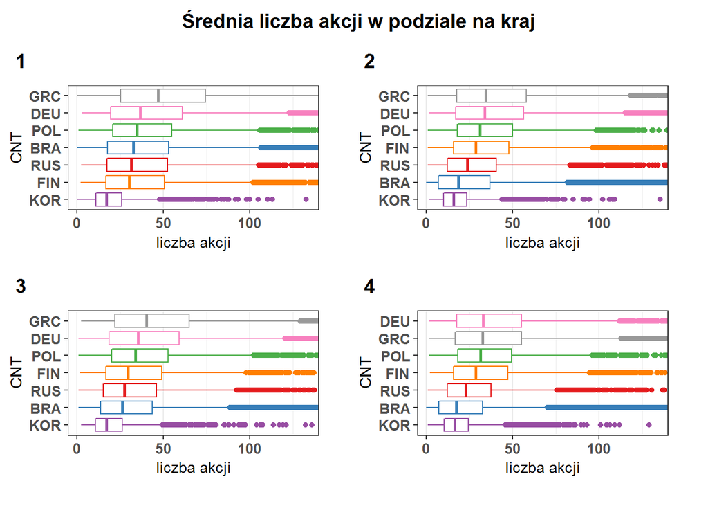

### 2.1.3 Średni wynik

Badamy różnice dla średniego wyniku w podziale na pozycje.

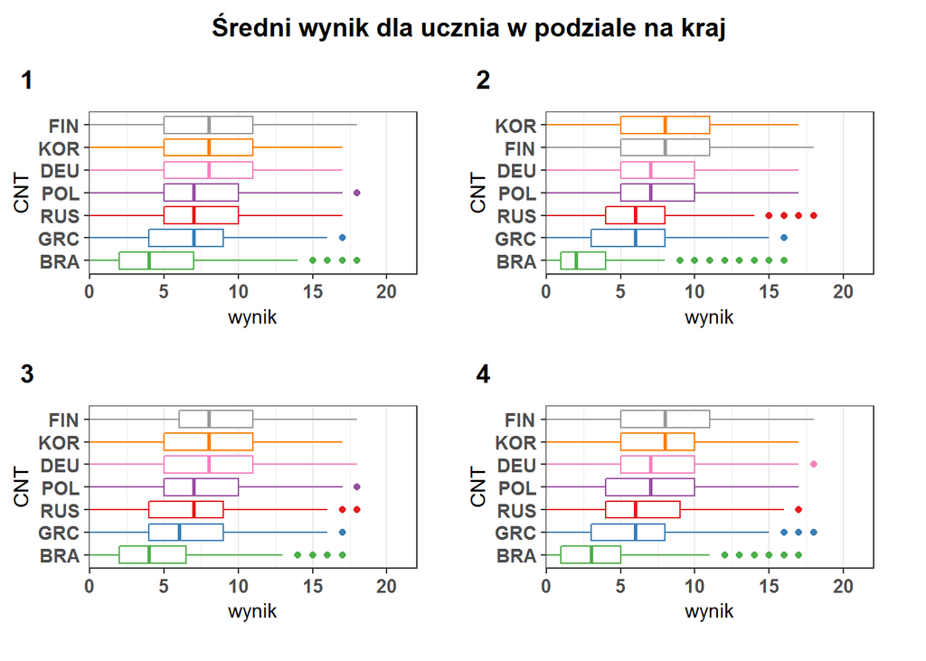

Kraje przodujące w rankingu (Korea, Finlandia) utrzymują w przybliżeniu stałą medianę wyników dla każdego poziomu. W ogólności pomiędzy poziomami nie obserwujemy dużej zmiany w kolejności wśród krajów.

### 2.1.4 Średni czas

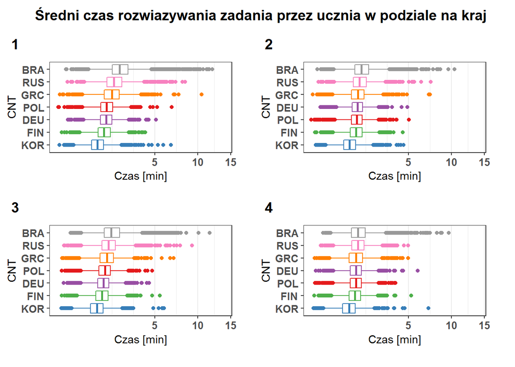

Na boxplotach nie obserwujemy wyraźnych różnic. Ponieważ jest to jeden z bardziej interesujących nas czynników, to wykonamy dla niego bardziej szczegółową analizę.

## 2.2. Podział ze względu na płeć

Dodatkowo sprawdzamy średni czas rozwiązywania zadania w zależności od pozycji w podziale na dziewczynki i chłopców.

### 2.2.1 Matematyka

[interactive chart not shown]

### 2.2.2 Czytanie

[interactive chart not shown]

### 2.2.3 Science

[interactive chart not shown]

# 3. SYNTAX

Korzystamy z pakietów:

```r
library(ggplot2)
library(dplyr)
library(stringi)
library(intsvy)
library(plotly)
library(tidyr)
library(markdown)
library(data.table)
library(cowplot)
```

Ładujemy dane:

```r
load("dane_06_06.Rda")
```

Skalujemy czas:

```r
dane$timing<-dane$timing/1000
dane$typ_zadania <- stri_sub(dane$item_short, length=1)
```

Odrzucamy dane z brakami oraz rekordy dla studentów ktorzy zrezygnowali z rozwiazywania testu - maja zbyt dlugi czas rozwiazywania.

```r
dane <- dane %>%
  filter(!is.na(timing) & !is.na(n.actions) & !is.na(result))

zrezygnowali <- dane %>% select(CNTSTUID,  position, timing)%>%
  filter(timing>3600) %>%
  group_by(CNTSTUID) %>%
  mutate(maksymalny=max(as.numeric(position)))

zrezygnowali <- zrezygnowali %>% filter( maksymalny==position )

dane1 <- dane[-which(dane$CNTSTUID %in% zrezygnowali$CNTSTUID),]
dane <- dane1
```

Obliczamy przykładowe statystyki oraz przedstawiamy je w formie tabeli.

```r
statystyki <- dane1 %>%
  group_by(CNT, position) %>%
  summarise( mean_scor = round(weighted.mean(result, w=weights),2),
             mean_time= round(mean(timing),2),
             med_time = round(median(timing),2),
             min_time = round(min(timing),2),
             max_time = round(max(timing),2),
             mean_n.actions = round(mean(n.actions),2),
             med_n.actions = median(n.actions),
             min_n.actions = min(n.actions),
             max_n.actions = max(n.actions))

save(statystyki, file="statystyki.Rda")

require(knitr)
kable(statystyki[1:10,])
```

Dokonujemy wyboru interesujących nas krajów:

```r
dane1 <- dane1 %>% filter(stri_trim(CNT) %in% c("POL","BRA","FIN","DEU","GRC","KOR","RUS"))
```

Dzielimy wczytany zbiór danych na informacje dotyczace każdej z pozycji.

```r
dane_position_1 <- dane1 %>% filter(position == 1)
dane_position_2 <- dane1 %>% filter(position == 2)
dane_position_3 <- dane1 %>% filter(position == 3)
dane_position_4 <- dane1 %>% filter(position == 4)
```

Wykonujemy boxploty korzystając dla każdej z pozycji z kodu:

```r
dane_position <- dane_position_1 %>% group_by(CNT, CNTSTUID) %>%
  summarise(mean_time=mean(timing), mean_action=mean(n.actions), final_result=sum(result))

dane_position$CNT <- reorder(dane_position$CNT,dane_position$mean_time, FUN=mean)

kolory <- c("#377eb8","#4daf4a","#984ea3","#e41a1c","#ff7f00","#f781bf","#999999")

 g1 <- ggplot(dane_position, aes(x = CNT, y = mean_time/60, color = CNT)) +
  geom_boxplot(colour=kolory) +
  coord_flip(expand=TRUE) +
  ylab("Czas [min]") +
  theme_bw() +
  theme(axis.text.x = element_text(hjust = 0.5, size=10, face="bold"),
        axis.text.y = element_text(hjust = 0.9, vjust=0.5, size=10, face="bold"),
        plot.title=element_text(margin=margin(b=0.5, unit="cm"), hjust=0, size=12, face="bold"),
        panel.grid.major.y=element_blank(),
        plot.margin=unit(c(1,1,0.5,0), "cm"))+
 scale_y_sqrt(expand = c(0, 0.03),limits=c(0,15))
```

A następnie wszystkie wykonane tak grafiki scalamy za pomocą poniższych funkcji:

```r
p <- plot_grid(g1, g2, g3, g4, labels=c("1", "2", "3", "4"), ncol = 2, nrow = 2)
title <- ggdraw() + draw_label("Średni czas rozwiazywania zadania przez ucznia w podziale na kraj", fontface='bold')
plot_grid(title, p, ncol=1, rel_heights=c(0.1, 1))
```

Wykres średniego czasu rozwiązywania zadania w zależności od pozycji w podziale na dziewczynki i chłopców wykonujemy za pomocą kodu:

```r
dane1 <- dane %>% group_by(CNT, ST004, typ_zadania, position) %>%
   summarise(mean_time=mean(timing), mean_action=mean(n.actions), final_result=sum(result))

p1 <- plotly_empty()
p2 <- plotly_empty()
p3 <- plotly_empty()
p4 <- plotly_empty()

dane_female <- dane1 %>% filter(ST004 == "Female", typ_zadania == "M", position == 1)
dane_male <- dane1 %>% filter(ST004 == "Male", typ_zadania == "M", position == 1)

tabela_plec <- inner_join(dane_female, dane_male, by = "CNT")
gender <- data.table(tabela_plec$CNT, tabela_plec$mean_time.x, tabela_plec$mean_time.y)
colnames(gender) <- c("CNT", "Female", "Male")
kraje <- gender %>% filter(stri_trim(CNT) %in% c("POL","BRA","FIN","DEU","GRC","KOR","RUS"))

pl <- ggplot(gender, aes(Female, Male, text=paste("Kraj:",CNT),color=CNT)) +
   geom_point() +
   geom_point(data=kraje, color="red",size=3) +
   geom_abline(slope=1, intercept = 0) +
   geom_abline(slope=1, intercept = 20, linetype = 2, color="grey") +
   geom_abline(slope=1, intercept = -20, linetype = 2, color="grey") +   coord_fixed(xlim = c(60,170), ylim = c(60,170)) +
   theme_classic() + ggtitle("Średni czas dla matematyki w podziale na płeć i pozycje") +
   xlab("Wynik dla dziewcząt") +
   ylab("Wynik dla chłopców")+
   theme(legend.position="none")

pl %>% ggplotly(originalData = FALSE, tooltip=c("text", "Female", "Male"), legend=FALSE) -> p1
```

Ostatecznie łączymy uzyskane interaktywne grafiki dla każdej tematyki poleceniem:

```r
plot1 <- subplot(p1, p2)
plot2 <- subplot(p3, p4)
p <- subplot(plot1, plot2, nrows = 2)
p %>% layout(annotations = list(
   list(x = 0.02 , y = 1.00, text = "1", showarrow = F, xref='paper', yref='paper'),
   list(x = 0.55 , y = 1.00, text = "2", showarrow = F, xref='paper', yref='paper'),
   list(x = 0.02 , y = 0.45, text = "3", showarrow = F, xref='paper', yref='paper'),
   list(x = 0.55 , y = 0.45, text = "4", showarrow = F, xref='paper', yref='paper'),
   list(x = 0.55 , y = -0.1, text = "dziewczynki", showarrow = F, xref='paper', yref='paper'),
   list(x = 0.2 , y =1, text = "chlopcy", showarrow = T, xref='paper', yref='paper')))
```